# 多尺度下物种入侵悖论的复现研究

跨尺度生态分析小组

2026-03-18

## 项目成员：

- 梅良2025303120116
- 师鑫2025303120092
- 陈希2025303110109
- 陈浩2025303110111

## 加载使用的包

- metafor # 元分析专用包
- plyr # 数据分组处理包（dplyr前身）
- polycor # 多列相关系数计算包
- readr # 快速读取文本/表格数据（tidyverse核心包）
- ggplot2 # 科研绘图包（tidyverse核心包）

### 关键说明

1. **代码块格式**：`` ```{r} ``` ``是R Markdown的语法，用于在文档中嵌入可运行的R代码，点击`Run Cell`即可执行。
2. **包的安装**：首次使用这些包需要先安装，执行`install.packages(c("metafor","plyr","polycor","readr","ggplot2"))`（`tidyverse`可一次性安装`install.packages("tidyverse")`）。
3. **科研场景适配**：这套包组合完全适配农业/生态/土壤科学的数据分析流程：元分析（metafor）→ 数据处理（plyr/tidyverse）→ 统计分析（polycor）→ 可视化（ggplot2）。

```r
library(metafor)
```

```r
library(plyr)
library(polycor)
library(readr)
library(ggplot2)
```

## 加载数据与数据前处理

```r
dat<- read_csv("../data/DataS2_MetaAnalysisDatabase.csv")
dat<-as.data.frame(dat)
dat$abs_Latitude <- abs(dat$Latitude)
```

## 图1及table2中的结果

### 元分析主模型结果解读

```r
random <- list(~ 1 | Study / Case)
metar <- rma.mv(yi = z, V = var_z, mods = ~ ln_Grain, random = random, data = dat, method = "ML")

###得到图1及table2中的结果
summary(metar)
```

```
##
## Multivariate Meta-Analysis Model (k = 204; method: ML)
##
##    logLik   Deviance        AIC        BIC       AICc
## -139.8439   711.4534   287.6877   300.9602   287.8887
##
## Variance Components:
##
##             estim    sqrt  nlvls  fixed      factor
## sigma^2.1  0.1072  0.3274    101     no       Study
## sigma^2.2  0.0847  0.2910    204     no  Study/Case
##
## Test for Residual Heterogeneity:
## QE(df = 202) = 7650.3942, p-val < .0001
##
## Test of Moderators (coefficient 2):
## QM(df = 1) = 33.8306, p-val < .0001
##
## Model Results:
##
##           estimate      se    zval    pval   ci.lb   ci.ub
## intrcpt     0.1294  0.0562  2.3029  0.0213  0.0193  0.2395    *
## ln_Grain    0.0373  0.0064  5.8164  <.0001  0.0247  0.0498  ***
##
## ---
## Signif. codes:  0 '***' 0.001 '**' 0.01 '*' 0.05 '.' 0.1 ' ' 1
```

```r
####计算该分层模型的I2
W <- diag(1/dat$var_z)
X <- model.matrix(metar)
P <- W - W %*% X %*% solve(t(X) %*% W %*% X) %*% t(X) %*% W
100 * sum(metar$sigma2) / (sum(metar$sigma2) + (metar$k-metar$p)/sum(diag(P)))
```

```
## [1] 98.2476
```

### 异质性分析解读

小 grain 下效应量异质性极高，正负相关并存；随 grain 增大异质性降低，效应趋于稳定正值。 说明小尺度受局部生物互作与随机波动影响大，而大尺度更能体现环境驱动的全局格局。

## 论文中图1的制作

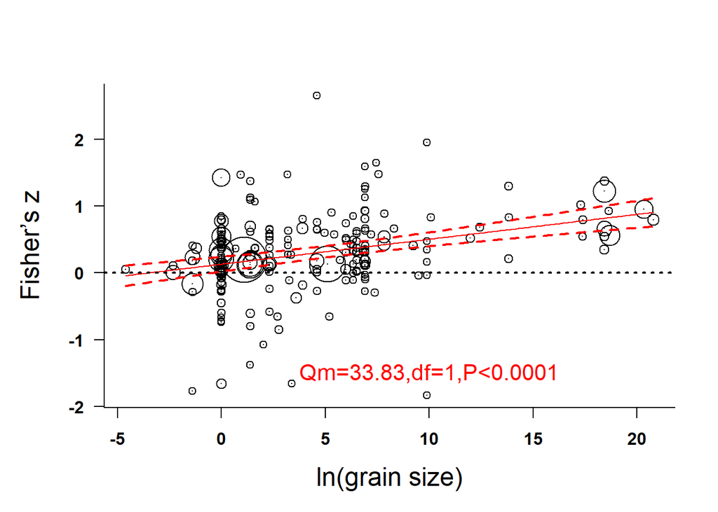

```r
par(mar=c(5.1,5.1,4.1,2.1))
new_ln_Grain<-seq(from = min(dat$ln_Grain),to = max(dat$ln_Grain), length = 204)
preds <- predict(metar, newmods=new_ln_Grain)
wi<- 1/dat$var_z
wi <- na.omit(wi)
size  <-1+ 5.0 * (wi - min(wi))/(max(wi) - min(wi))

plot(dat$ln_Grain, dat$z, pch=1, cex=size, col="black",
         xlab="ln(grain size)", ylab="Fisher’s z",
         las=1, bty="l", font=2,cex.lab=1.5)
points(dat$ln_Grain, dat$z, pch=16, cex=0.1)
lines(new_ln_Grain, preds$pred,col="red")
abline(h=0, lty="dotted",col="black",lwd=2)
lines(new_ln_Grain, preds$ci.lb, lty="dashed",lwd=2,col="red")
lines(new_ln_Grain, preds$ci.ub, lty="dashed",lwd=2,col="red")
text(c(10), -1.5, c("Qm=33.83,df=1,P<0.0001"),cex=1.3,font=1,col="red")
```

## table2中habitat及Fig2B结果

### 地理格局分析解读

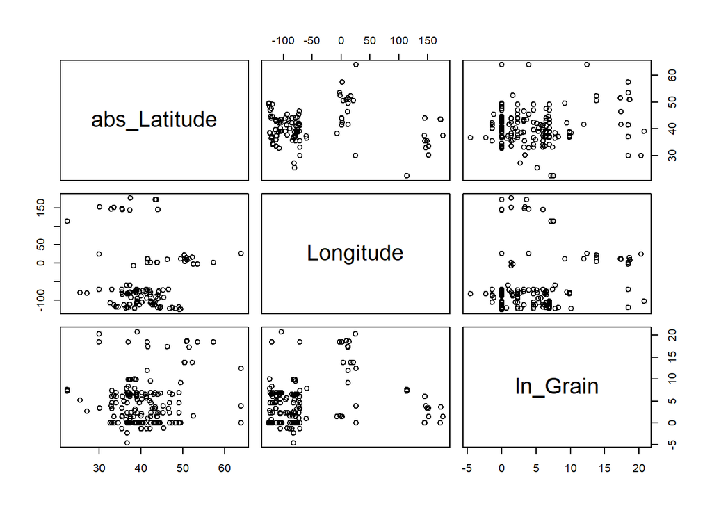

```r
pairs(~ abs_Latitude + Longitude + ln_Grain, data = dat)
```

```r
dat$Habitat_type<-as.factor(dat$Habitat_type)
dat$Extent<-as.ordered(dat$Extent)

hetcor(data = dat[, c("ln_Grain", "abs_Latitude", "Longitude", "Extent", "Habitat_type")], std.err = FALSE)
```

```
##
## Two-Step Estimates
##
## Correlations/Type of Correlation:
##              ln_Grain abs_Latitude Longitude     Extent Habitat_type
## ln_Grain            1      Pearson   Pearson Polyserial   Polyserial
## abs_Latitude   0.0804            1   Pearson Polyserial   Polyserial
## Longitude      0.1519      -0.0057         1 Polyserial   Polyserial
## Extent         0.2523       0.1563   0.01598          1   Polychoric
## Habitat_type  0.06722     -0.05996     0.296     0.1092            1
```

```r
lat <- rma.mv(yi = z, V = var_z, mods = ~ abs_Latitude, random = random, data = dat, method = "ML")
lon2 <- rma.mv(yi = z, V = var_z, mods = ~ Longitude + I(Longitude^2), random = random, data = dat, method = "ML")
ext <- rma.mv(yi = z, V = var_z, mods = ~ -1 + Extent, random = random, data = dat, method = "ML")
ext.ord <- rma.mv(yi = z, V = var_z, mods = ~ ordered(Extent), random = random, data = dat, method = "ML")
summary(ext.ord)
```

```
##
## Multivariate Meta-Analysis Model (k = 204; method: ML)
##
##    logLik   Deviance        AIC        BIC       AICc
## -152.8424   737.4504   323.6847   353.5478   324.6125
##
## Variance Components:
##
##             estim    sqrt  nlvls  fixed      factor
## sigma^2.1  0.1535  0.3918    101     no       Study
## sigma^2.2  0.0899  0.2998    204     no  Study/Case
##
## Test for Residual Heterogeneity:
## QE(df = 197) = 9297.2108, p-val < .0001
##
## Test of Moderators (coefficients 2:7):
## QM(df = 6) = 4.8876, p-val = 0.5583
##
## Model Results:
##
##                    estimate      se     zval    pval    ci.lb   ci.ub
## intrcpt              0.3411  0.0521   6.5503  <.0001   0.2390  0.4431  ***
## ordered(Extent).L    0.0635  0.1331   0.4773  0.6332  -0.1973  0.3243
## ordered(Extent).Q    0.2350  0.1300   1.8079  0.0706  -0.0198  0.4897    .
## ordered(Extent).C    0.0879  0.1328   0.6622  0.5078  -0.1723  0.3481
## ordered(Extent)^4   -0.0866  0.1169  -0.7411  0.4586  -0.3157  0.1425
## ordered(Extent)^5   -0.0331  0.1220  -0.2712  0.7862  -0.2723  0.2061
## ordered(Extent)^6   -0.1002  0.1198  -0.8357  0.4033  -0.3350  0.1347
##
## ---
## Signif. codes:  0 '***' 0.001 '**' 0.01 '*' 0.05 '.' 0.1 ' ' 1
```

```r
subset.hab <- dat[which(dat$Habitat_type != "many"), ]
hab.full <- rma.mv(yi = z, V = var_z, mods = ~ -1 + Habitat_type, random = random, data = dat, method = "ML")
hab <- rma.mv(yi = z, V = var_z, mods = ~ -1 + Habitat_type, random = random, data = subset.hab, method = "ML")
hab.Q <- rma.mv(yi = z, V = var_z, mods = ~ Habitat_type, random = random, data = subset.hab, method = "ML")
summary(hab.Q)
```

```
##
## Multivariate Meta-Analysis Model (k = 173; method: ML)
##
##    logLik   Deviance        AIC        BIC       AICc
## -130.2003   598.3715   276.4007   301.6270   277.2787
##
## Variance Components:
##
##             estim    sqrt  nlvls  fixed      factor
## sigma^2.1  0.1314  0.3625     77     no       Study
## sigma^2.2  0.0946  0.3075    173     no  Study/Case
##
## Test for Residual Heterogeneity:
## QE(df = 167) = 4003.2783, p-val < .0001
##
## Test of Moderators (coefficients 2:6):
## QM(df = 5) = 8.9418, p-val = 0.1114
##
## Model Results:
##
##                        estimate      se     zval    pval    ci.lb   ci.ub
## intrcpt                  0.2836  0.1741   1.6294  0.1032  -0.0575  0.6248
## Habitat_typeforest      -0.0003  0.1984  -0.0014  0.9989  -0.3891  0.3885
## Habitat_typegrassland   -0.1275  0.1869  -0.6823  0.4950  -0.4939  0.2388
## Habitat_typeshrubland   -0.0034  0.2327  -0.0147  0.9883  -0.4594  0.4526
## Habitat_typeurban        0.5475  0.2685   2.0390  0.0415   0.0212  1.0739  *
## Habitat_typewetland     -0.0153  0.1997  -0.0768  0.9388  -0.4067  0.3760
##
## ---
## Signif. codes:  0 '***' 0.001 '**' 0.01 '*' 0.05 '.' 0.1 ' ' 1
```

```r
###I2的计算
W <- diag(1/subset.hab$var_z)
X <- model.matrix(hab.Q)
P <- W - W %*% X %*% solve(t(X) %*% W %*% X) %*% t(X) %*% W
100 * sum(hab.Q$sigma2) / (sum(hab.Q$sigma2) + (hab.Q$k-hab.Q$p)/sum(diag(P)))
```

```
## [1] 98.2869
```

## Fig.2b作图

```r
coef(summary(hab))
```

```
##                           estimate         se     zval         pval       ci.lb
## Habitat_typeagricultural 0.2836161 0.17405868 1.629428 1.032224e-01 -0.05753264
## Habitat_typeforest       0.2833425 0.09631769 2.941749 3.263644e-03  0.09456326
## Habitat_typegrassland    0.1560702 0.09824366 1.588603 1.121499e-01 -0.03648382
## Habitat_typeshrubland    0.2801961 0.15565515 1.800108 7.184362e-02 -0.02488244
## Habitat_typeurban        0.8311537 0.20456436 4.063043 4.843718e-05  0.43021492
## Habitat_typewetland      0.2682731 0.09814266 2.733501 6.266485e-03  0.07591702
##                              ci.ub
## Habitat_typeagricultural 0.6247648
## Habitat_typeforest       0.4721217
## Habitat_typegrassland    0.3486243
## Habitat_typeshrubland    0.5852745
## Habitat_typeurban        1.2320925
## Habitat_typewetland      0.4606292
```

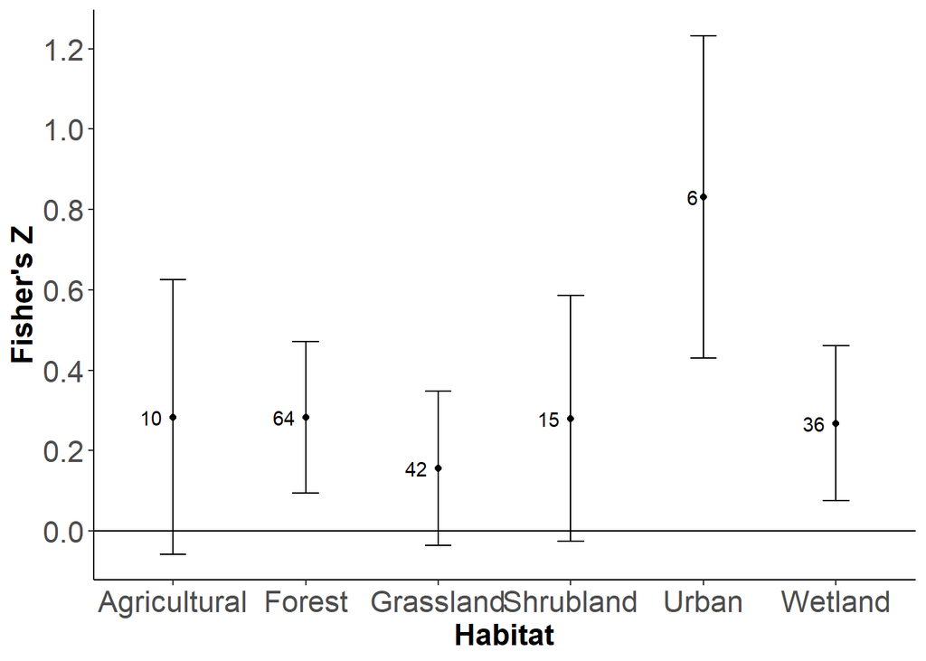

```r
estimates4 <- coef(summary(hab))[,1]
se4 <- coef(summary(hab))[,2]
variances4<- se4^2

dd1<-as.data.frame(table(subset.hab$Habitat_type))

samplesize<-as.data.frame(dd1$Freq)
samplesize<-samplesize[-4,]
labels4 <- c("Agricultural", "Forest", "Grassland", "Shrubland", "Urban", "Wetland")
dat2<-as.data.frame(cbind(labels4,estimates4,se4))

dat2$estimates4 <- as.numeric(as.character(dat2$estimates4))
dat2$se4 <- as.numeric(as.character(dat2$se4))
dat2$samplesize <- samplesize

ggplot(dat=dat2,aes(x=labels4, y=estimates4))+geom_point()+
geom_errorbar(aes(ymin=estimates4-1.96*se4,
                  ymax=estimates4+1.96*se4),
              width=.2)+
             theme_bw() +
             labs(x="Habitat",y="Fisher's Z")+
             scale_y_continuous(breaks = seq(-0.2, 1.2, by = 0.2))+
             theme(panel.border = element_blank(),
             panel.grid.major = element_blank(),
             panel.grid.minor = element_blank(),
             axis.line = element_line(colour = "black"))+
             theme(axis.text=element_text(size=16),
             axis.title=element_text(size=16,face="bold"))+
             geom_hline(yintercept =0)+
  geom_text(aes(label=samplesize), hjust=1.5)
```

## Fig.S1作图

### 漏斗图绘制说明

本代码基于metafor包实现元分析漏斗图绘制，用于识别研究间的发表偏倚。 1. 分别拟合多水平元分析模型（randomonly）与常规随机效应模型（randomonly2）； 2. 绘制带90%/95%/99%置信区间的轮廓增强漏斗图，以标准误为纵轴； 3. 添加红色实线标记合并效应量位置，直观展示效应量分布与偏倚特征。

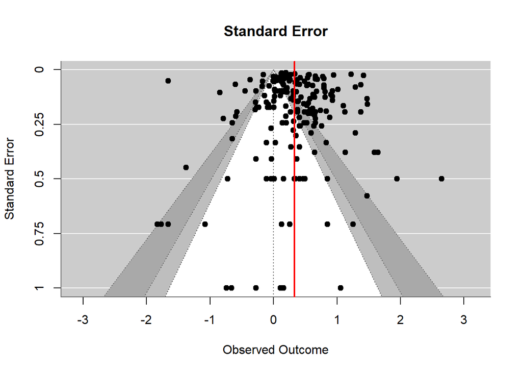

```r
randomonly <- rma.mv(yi = z, V = var_z, random = random, data = dat, method = "REML")
randomonly2 <- rma(yi = z, vi = var_z, data = dat)
funnel(randomonly2, level=c(90, 95, 99),
       shade=c("white", "gray", "darkgray"), refline=0,
       main="Standard Error")
abline(v=randomonly$b, lty="solid",col="red",lwd=2)
```